# IE423 Project Part-2

Enes Köser, Abdullatif Aydın,Omer Faruk Cavas,Muhammet Avni Ulusoy,Mustafa Keser

01 12 2019

## Task 1

In this part of the project, we are asked to find out of control pixels using the grayscale version of the photo that is given to us. When we make the photo grayscale, it becomes 2 dimensions and we create the new photo accordingly. In order to find out of control pixels, we take the mean of the first row of the photograph with 400 * 400 dimension. After finding Mean, we calculate the standard deviation of the specified row. Once standard deviation is found, we can create a six sigma control chart. After the control chart is created, we set the out of control pixels to 0 and repeat this process for each row and column. Eventually, we can plot the data and compare the original image with the new image which was arranged according to six sigma control charts.

To apply required processes, firstly we installed required packages.

```r
#install.packages("jpeg")
library(jpeg)
library("graphics")
```

We read the image, examine structure and dimensions of it.

```r
#read the gray scaled version of the original image
img <- readJPEG("C:/Users/omerf/group_3gray.jpeg")

#Structure of the img variable
str(img)
```

```
##  num [1:400, 1:400, 1:3] 0.251 0.282 0.329 0.282 0.275 ...
```

```r
#Dimensions of the img variable
dim(img)
```

```
## [1] 400 400   3
```

Then, we plotted the image.

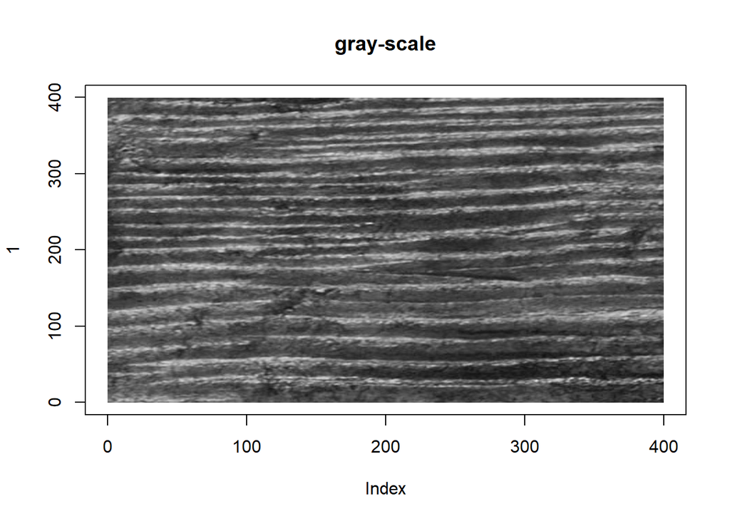

```r
#Plot the grayscaled image
img <- img[,,1]
par(mfrow=c(1,1))
plot(1, type="n", xlim=c(0, 400), ylim=c(0, 400), main = "gray-scale")

rasterImage(img[,],0, 0, 400, 400)
```

We plotted the histogram. The histogram is right-skewed because image is grayscale and it has mostly gray values. That leads to see more pixels values close to zero.

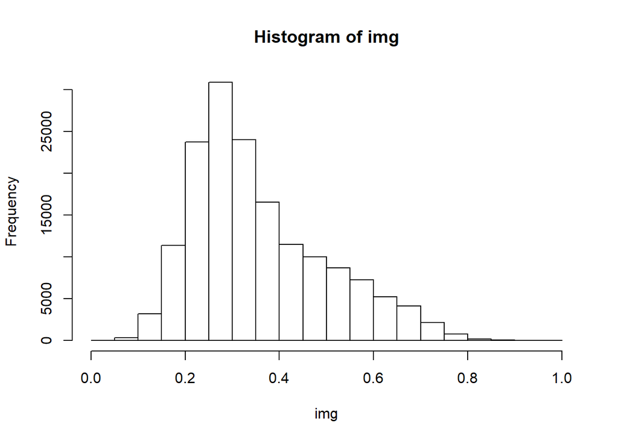

```r
#Plot the histogram of the image
hist(img)
```

For the example, we created a control chart for the first row of the img and plotted it. Red lines represent the upper and lower control limits. Dots represent the values. It can be seen from the plot that at some part of the row, values goes up significantly.

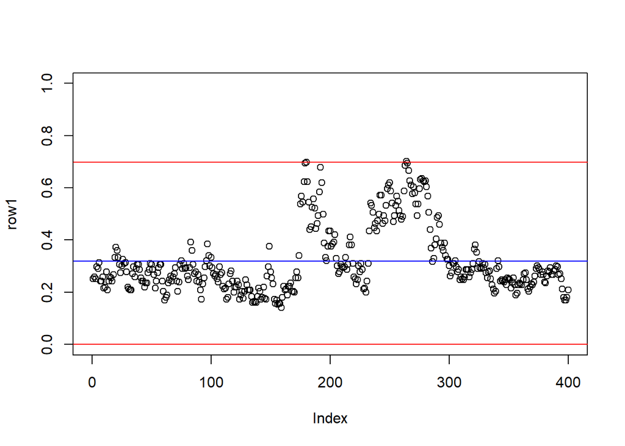

```r
#Create a x control chart for row1
row1 <- img[1,]

cl <- mean(row1)
ucl <- mean(row1) + 3*sd(row1)
lcl <- max(0, mean(row1) - 3*sd(row1))

plot(row1, xlim=c(0, 400), ylim=c(0, 1))
abline(h=mean(row1), col="blue")
abline(h=ucl, col="red")
abline(h=lcl, col="red")
```

With the same way, we created a control chart for rows and changed out of control pixels to zero. The result can be seen from plotted images. From the plots we can see out of control points due to misalignment in horizantal lines at the bottom left of the image. Other out of control points are also mostly around misaligned lines.

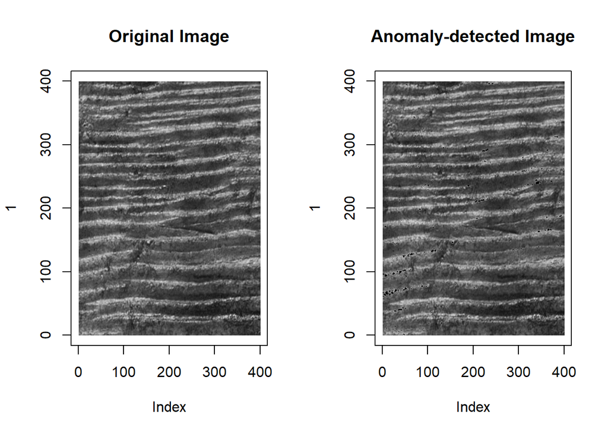

```r
#Create a control chart for ROWS
img_new <- img

for (i in 1:400) {
  ucl <- mean(img[i,]) + 3*sd(img[i,])
  lcl <- max(0, mean(img[i,]) - 3*sd(img[i,]))

  #Identify and change the values of the pixels which are out of the control limits (detect anomalies in the image)
  for(j in 1:400) {
    if(img[i,j] < lcl | img[i,j] > ucl) {
      img_new[i,j] = 0
    }
    else {img_new[i,j] = img[i,j]}
  }

}
#Plot the new anomaly wrt rows detected image with original image
par(mfrow=c(1,2))

plot(1, type="n", xlim=c(0, 400), ylim=c(0, 400), main = "Original Image")
rasterImage(img[,],0, 0, 400, 400)

plot(1, type="n", xlim=c(0, 400), ylim=c(0, 400), main = "Anomaly-detected Image")
rasterImage(img_new[,],0, 0, 400, 400)
```

Besides, we created control chart for the columns. Same processes are made for columns, too.After we create the control charts for columns, we have seen that out of control points generally occur on white points, which may be because our image is mostly gray.

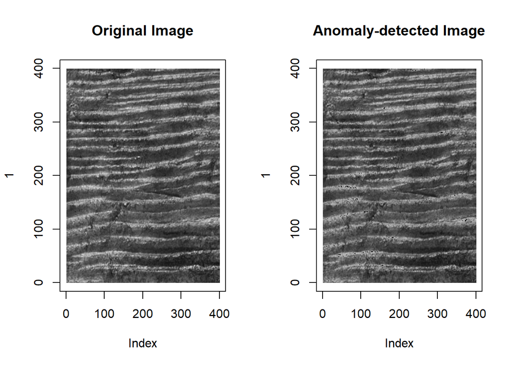

```r
#Create a control charts for COLUMNS
img_new <- img

for (i in 1:400) {
  ucl <- mean(img[,i]) + 3*sd(img[,i])
  lcl <- max(0, mean(img[,i]) - 3*sd(img[,i]))

  #Identify and change the values of the pixels which are out of the control limits (detect anomalies in the image)
  for(j in 1:400) {
    if(img[i,j] < lcl | img[i,j] > ucl) {
      img_new[i,j] = 0
    }
    else {img_new[i,j] = img[i,j]}
  }

}
#Plot the new anomaly wrt columns detected image with original image
par(mfrow=c(1,2))

plot(1, type="n", xlim=c(0, 400), ylim=c(0, 400), main = "Original Image")
rasterImage(img[,],0, 0, 400, 400)

plot(1, type="n", xlim=c(0, 400), ylim=c(0, 400), main = "Anomaly-detected Image")
rasterImage(img_new[,],0, 0, 400, 400)
```

## Task 2

At first we downloaded the required library.

```r
#install.packages("jpeg")
library(jpeg)
```

Then, we read the image with readJPEG function and plotted it.

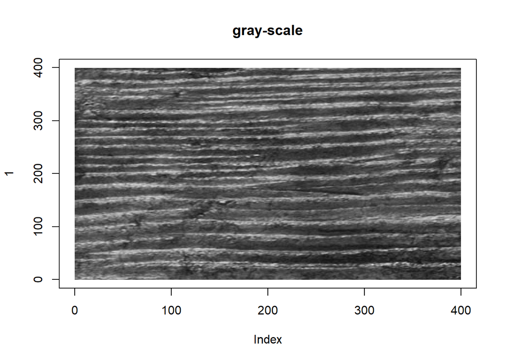

Now, we need to construct a linear regression model that predicts center pixel values of each 51x51 window. Other pixels will be the explanatory variables. To be able to fit regression model, we should prepare a dataframe. Due to the long time that is required to fit all values, we construct the model with a small dataframe. We gather that dataframe by taking values three by three.

In order to predict all center values, we gather all values in a dataframe that has 350x350(122500) rows. Besides, number of columns in dataframe will be 51x51(2601) due to number of pixels in the windows.

```r
#Create an empty matrix for regression (for original image --> nrow = 350*350 = 122500, ncol = 51*51 = 2601)
df_allpix <- matrix(0, nrow = 122500, ncol = 2601)

n <- 51  #Size of the window
k <- 400  #Size of the original image
#Create df for the all windows (This df will be used for prediction)
row_ind <- 1
for (i in (((n+1)/2) : (k - (n-1)/2))){
  for (j in (((n+1)/2) : (k - (n-1)/2))){

    df_allpix[row_ind,] <- as.vector(img[(i-25):(i+25),(j-25):(j+25)])
    row_ind <- row_ind+1
  }
}
#Convert the data type of df_allpix object from matrix to dataframe
df_allpix <- as.data.frame(df_allpix)
```

In order to construct model, we created a dataframe with 117*117(13689) rows and 51x51(2601) columns by passing over the pixels three by three.

```r
#Crate df by getting windows by 3 steps (This df will be used to construct linear model)
df_trainpix <- matrix(0, nrow = 13689, ncol = 2601) #117*117=13689 windows were used

row_ind <- 1
for (i in seq((n+1)/2, k - (n-1)/2, by = 3)){
  for (j in seq((n+1)/2, k - (n-1)/2, by = 3)){

    df_trainpix[row_ind,] <- as.vector(img[(i-25):(i+25),(j-25):(j+25)])
    row_ind <- row_ind+1

  }
}
#Convert the data type of df_trainpix object from matrix to dataframe
df_trainpix <- as.data.frame(df_trainpix)
```

We constructed the linear regression with the data we obtained above.

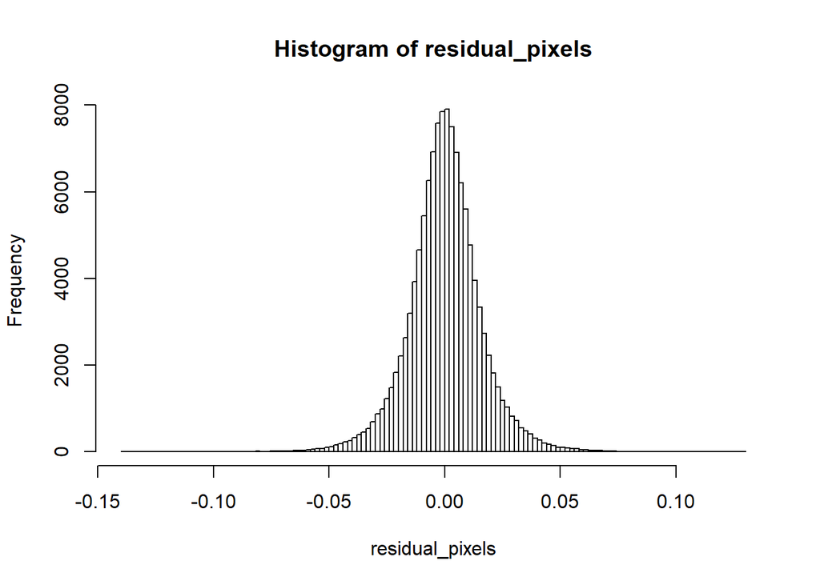

```r
#Construct linear model predicting centeral pixel values of each window
linearMod  <- lm(V1301~., data = df_trainpix)

#Predict all center pixel values
predicted <- predict(linearMod, newdata = df_allpix)

#Get the difference(residuals) between actual and predicted pixel values
residual_pixels <- as.vector(predicted - df_allpix$V1301)

#Plot the histogram of the residuals to check normality
hist(residual_pixels, nclass = 100)
```

After constructing the linear regression, we should find residuals and create a control chart for them. Hence we got residuals from model and created a control chart and plotted it.From the figure below, we can see that there are lots of out of control points,both above the upper limit and below the lower limit.

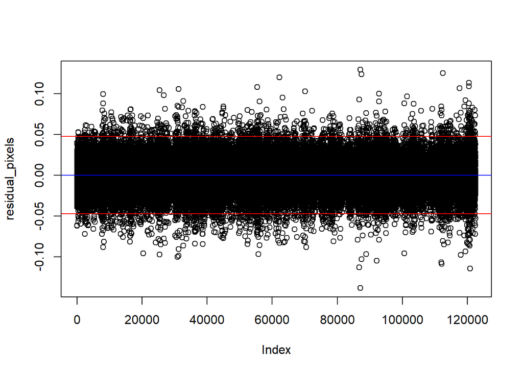

```r
#Create limits for control chart for residuals
cl <- mean(residual_pixels)
ucl <- mean(residual_pixels) + 3*sd(residual_pixels)
lcl <- mean(residual_pixels) - 3*sd(residual_pixels)

#Plot the control chart
par(mfrow=c(1,1))
plot(residual_pixels)
abline(h=cl, col="blue")
abline(h=ucl, col="red")
abline(h=lcl, col="red")
```

In the project it is asked to change pixel values with residuals that are out of control to zero. Therefore, we created a residual matrix and determined the pixels corresponding to residuals that are out of control with a for loop. Then,we changed those pixels in the orjinal image to zero.

```r
#Create a matrix from obtained residual vector
residual_matrix <- matrix(residual_pixels, nrow = 350, ncol = 350, byrow = TRUE)

#Identify and change the values of the pixels which are out of the control limits (detect anomalies in the image)
img_new = img #img is the original image, img_new is the anomaly-detected image

counter = 0
for (i in 1:(k-n+1)) {
  for (j in 1:(k-n+1)) {

    if(residual_matrix[i,j] < lcl | residual_matrix[i,j] > ucl) {
      img_new[i+25,j+25] = 0
      counter <- counter+1
    }
  }
}
#Print the number of pixels which are out of control limits
counter
```

```
## [1] 1503
```

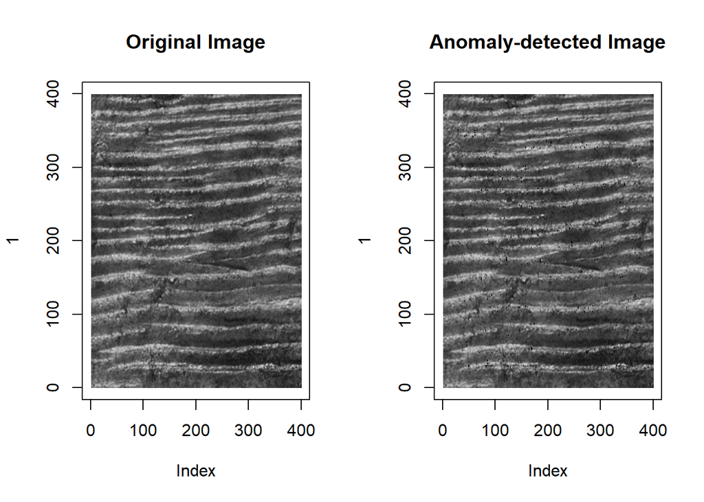

```r
#Plot the new anomaly detected image along with the original image
par(mfrow=c(1,2))

plot(1, type="n", xlim=c(0, 400), ylim=c(0, 400), main = "Original Image")
rasterImage(img[,],0, 0, 400, 400)

plot(1, type="n", xlim=c(0, 400), ylim=c(0, 400), main = "Anomaly-detected Image")
rasterImage(img_new[,],0, 0, 400, 400)
```

Since we have some factors with a high correlation, we may have multicollinearity between some predictors. Because they give same information, removing one of the correlated factors usually doesn’t drastically reduce the model accuracy. We may consider using stepwise regression to remove these variables, but we may not determine the correct predictors to remove due to similarity of factors. Another approach that we advice is taking the average of the rows in the window of size 51*51 instead of using each pixel value, and predicting the center pixel value by these 51 factors. This can be reasonable especially for our image since it consists of horizantal lines with similar pixel values which may cause autocorrelation.